# Regional statistics and trends in dissimilarity by region

Zoë J. Kitchel

September 16, 2024

Script 7 for Kitchel et al. 2024 in prep taxonomic diversity manuscript.

```r
library(data.table)
library(ggplot2)
library(sf)
library(concaveman)
library(raster)
library(stringr)
library(rnaturalearth)
library(rmapshaper)
library(nlme)
library(MuMIn)
library(cowplot)
library(lme4)
library(lubridate)
#pull in function to calculate model estimates and standard errors
source(here::here("analysis_code","extract_coefficients_function.R"))
```

Load data

```r
#raw data
FishGlob_clean.singleseason <- readRDS(here::here("data", "cleaned", "FishGlob_clean.singleseason.rds"))

#model coefficients from year_dissimilarity_jaccard_4a.Rmd
jaccard_total_coefs.r <- fread(here::here("output","jaccard_total_coefs.r.csv"))
jaccard_total_coefs.r[,`Significant Trends`:= ifelse(differentiating == 1, "differentiating",ifelse(homogenizing == 1,"homogenizing","no trend"))]

jaccard_abundance_total_coefs.r <- fread(here::here("output","jaccard_abundance_total_coefs.r.csv"))
jaccard_abundance_total_coefs.r[,`Significant Trends`:= ifelse(differentiating == 1, "differentiating",ifelse(homogenizing == 1,"homogenizing","no trend"))]


#NB: years sampled = last_year-first_year+1

#Dissimilarity values
jaccard_index_allyears <- readRDS(here::here("output","jaccard_index_VEGAN","jaccard_index_allyears.rds"))
```

Pull in palette and name helper

```r
source(here::here("analysis_code","color_links.R"))
```

```r
all_survey_units <- unique(FishGlob_clean.singleseason[, survey_unit])
```

Flag abundance and biomass subsets

```r
abun_subset <- c(
"BITS-1",
"EVHOE",
"FR-CGFS",
"IE-IGFS",
"MEDITS",
"NIGFS-1",
"NS-IBTS-1",
"PT-IBTS",
"ROCKALL",
"SWC-IBTS-1",
"AI",
"DFO-NF",
"EBS",
"GMEX-Fall",
"GOA",
"GRL-DE",
"GSL-N",
"GSL-S",
"ICE-GFS",
"NEUS-Fall",
"Nor-BTS-3",
"SCS-SUMMER",
"SEUS-summer",
"WCANN"
)

bio_subset <- c(
"CHL",
"DFO-QCS",
"NAM",
"NZ-CHAT",
"NZ-ECSI",
"NZ-SUBA",
"NZ-WCSI",
"S-GEORG",
"ZAF-ATL",
"ZAF-IND",
"AI",
"DFO-NF",
"EBS",
"GMEX-Fall",
"GOA",
"GRL-DE",
"GSL-N",
"GSL-S",
"ICE-GFS",
"NEUS-Fall",
"Nor-BTS-3",
"SCS-SUMMER",
"SEUS-summer",
"WCANN"
)
```

Define sum and mean functions to handle NAs appropriately

```r
#Define function to correctly sum across duplicates (sum(NA,NA,NA) = NA, while sum(1,NA,NA) = 1, which is not the default for na.rm parameter)

my_sum <- function(x){
  if(all(is.na(x))){
    return(as.numeric(NA))
  }
  else{
    return(sum(x, na.rm = TRUE))
  }
}

#Define function to correctly sum across duplicates (sum(NA,NA,NA) = NA, while sum(1,NA,NA) = 1, which is not the default for na.rm parameter)

my_mean <- function(x){
  if(all(is.na(x))){
    return(as.numeric(NA))
  }
  else{
    return(mean(x, na.rm = TRUE))
  }
}
```

Regional characteristics

```r
#make depth numeric
FishGlob_clean.singleseason[,depth := as.numeric(depth)]

#make survey and survey unit factors
FishGlob_clean.singleseason[,survey:=factor(survey)][,survey_unit:=factor(survey_unit)]

#adjust years
FishGlob_clean.singleseason[,year_adj := year-min(year)+1]

#add column for yearly summed # of hauls
FishGlob_clean.singleseason[,haul_id_count_annual := uniqueN(haul_id),.(year, survey_unit)]

#add column for yearly summed # of spp
FishGlob_clean.singleseason[,spp_count_annual := uniqueN(accepted_name),.(year, survey_unit)]

#add column for avg depth per year
FishGlob_clean.singleseason[,depth_annual_avg := my_mean(depth),.(year, survey_unit)]

#add column for depth range per year
FishGlob_clean.singleseason[, depth_annual_range :=
  if (all(is.na(depth))) {
    NA_real_
  } else {
    max(depth, na.rm = TRUE) - min(depth, na.rm = TRUE)
  },
  by = .(year, survey_unit)
]

#add column for avg latitude per year
FishGlob_clean.singleseason[,latitude_annual_avg := my_mean(as.numeric(latitude)),.(year, survey_unit)]

#add column for latitude range per year
FishGlob_clean.singleseason[,latitude_annual_range := max(latitude, na.rm =T)-min(latitude, na.rm =T),.(year, survey_unit)]


#for some reason this step is causing issues turning a numeric column into logical, so we're going to manually implement this by merging DT...ugh
num_cpue_annual_byreg<- FishGlob_clean.singleseason[survey_unit %in% abun_subset, .(num_cpue_annual =
 my_sum(num_cpue)),
  by = .(year, survey_unit)]

#Merge back
FishGlob_clean.singleseason <- num_cpue_annual_byreg[FishGlob_clean.singleseason, on = c("year","survey_unit")]


#unique rows
FishGlob_richness_year_survey <- unique(FishGlob_clean.singleseason[,.(survey_unit, year, num_cpue_annual, haul_id_count_annual, spp_count_annual, depth_annual_avg,depth_annual_range, latitude_annual_avg, latitude_annual_range)])

FishGlob_richness_year_survey[,year_adj := year-min(year)+1]


saveRDS(FishGlob_richness_year_survey, file = here::here("output","FishGlob_richness_year_survey.Rds"))
fwrite(FishGlob_richness_year_survey, file = here::here("output","FishGlob_richness_year_survey.csv"))
```

Calculate coefficients from lm for trend in species richness within a region over time

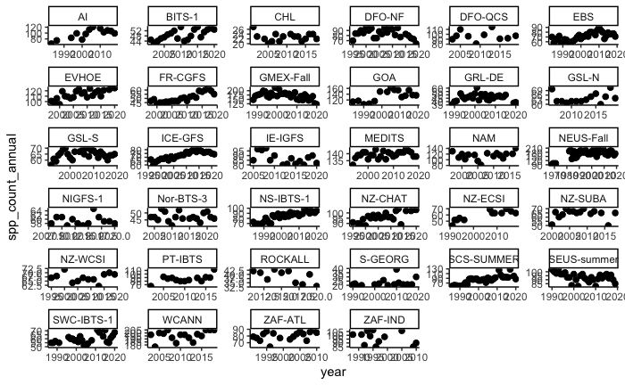

```r
#plot year vs richness for each reg
ggplot(data = FishGlob_richness_year_survey) +
  geom_point(aes(x = year, y = spp_count_annual), size = 2) +
  facet_wrap(~survey_unit, scales = "free") +
  theme_classic()
```

```r
#simple lm
richness_trend_lm <- lm(spp_count_annual ~ year*survey_unit, data = FishGlob_richness_year_survey)

#Use linear algebra to calculate coefficients and standard errors
spp_richness_coefs.r <- data.table(lm_interaction_coefficients_se(richness_trend_lm))

#Add survey names
spp_richness_coefs.r[,survey_unit := sort(unique(jaccard_index_allyears$survey_unit))]

  colnames(spp_richness_coefs.r) <- c("term","survey_unit_richness_coefficient","richness_coefficient_error","t-value","p-value","survey_unit")

  spp_richness_coefs.r <- spp_richness_coefs.r[,.(survey_unit, survey_unit_richness_coefficient, richness_coefficient_error)]

#export this table
fwrite(spp_richness_coefs.r, file = here::here("output","spp_richness_coefs.r.csv"))
```

Link trend in beta diversity to trend in gamma diversity

```r
library(ggrepel)
#merge
#jaccard
trend_coefs_jaccard <- spp_richness_coefs.r[jaccard_total_coefs.r, on = c("survey_unit")]

trend_coefs_jaccard <- color_link[trend_coefs_jaccard, on = "survey_unit"]

trends_beta_gamma_jaccard <- ggplot(data = trend_coefs_jaccard, aes(x = survey_unit_richness_coefficient, y = estimate)) +
  geom_hline(yintercept = 0, color = "grey", linetype = "dashed") +
  geom_vline(xintercept = 0, color = "grey", linetype = "dashed") +
  geom_point() +
  geom_text_repel(aes(label = Survey_Name_Season), size = 2.5) + # Use geom_text_repel
  labs(x = "Trend in γ-diversity", y = "Trend in β-diversity\n(Jaccard dissimilarity)") +
  theme_classic()

ggsave(trends_beta_gamma_jaccard, path = here::here("figures"), filename = "trends_beta_gamma_jaccard.jpg", height = 7, width = 7)

 #linear model?
summary(lm(estimate~survey_unit_richness_coefficient, data = trend_coefs_jaccard))
```

```
Call:
lm(formula = estimate ~ survey_unit_richness_coefficient, data = trend_coefs_jaccard)

Residuals:
       Min         1Q     Median         3Q        Max
-0.0045989 -0.0008935  0.0000966  0.0010535  0.0042039

Coefficients:
                                   Estimate Std. Error t value Pr(>|t|)
(Intercept)                      -0.0003404  0.0003704  -0.919   0.3649
survey_unit_richness_coefficient  0.0010627  0.0005502   1.932   0.0623 .
---
Signif. codes:  0 ‘***’ 0.001 ‘**’ 0.01 ‘*’ 0.05 ‘.’ 0.1 ‘ ’ 1

Residual standard error: 0.001921 on 32 degrees of freedom
Multiple R-squared:  0.1044,    Adjusted R-squared:  0.07644
F-statistic: 3.731 on 1 and 32 DF,  p-value: 0.0623
```

```r
#and when rockall removed
summary(lm(estimate~survey_unit_richness_coefficient, data = trend_coefs_jaccard[survey_unit != "ROCKALL",]))
```

```
Call:
lm(formula = estimate ~ survey_unit_richness_coefficient, data = trend_coefs_jaccard[survey_unit !=
    "ROCKALL", ])

Residuals:
       Min         1Q     Median         3Q        Max
-0.0035596 -0.0012590  0.0001308  0.0009528  0.0039136

Coefficients:
                                   Estimate Std. Error t value Pr(>|t|)
(Intercept)                      -4.406e-05  3.517e-04  -0.125    0.901
survey_unit_richness_coefficient  6.013e-04  5.247e-04   1.146    0.261

Residual standard error: 0.00174 on 31 degrees of freedom
Multiple R-squared:  0.04065,   Adjusted R-squared:  0.009703
F-statistic: 1.314 on 1 and 31 DF,  p-value: 0.2605
```

```r
##JACCARD ABUNDANCE
trend_coefs_jaccard_abundance <- spp_richness_coefs.r[jaccard_abundance_total_coefs.r, on = c("survey_unit")]

trend_coefs_jaccard_abundance <- color_link[trend_coefs_jaccard_abundance, on = "survey_unit"]

trends_beta_gamma_jaccard_abundance <- ggplot(data = trend_coefs_jaccard_abundance, aes(x = survey_unit_richness_coefficient, y = estimate)) +
  geom_hline(yintercept = 0, color = "grey", linetype = "dashed") +
  geom_vline(xintercept = 0, color = "grey", linetype = "dashed") +
  geom_point() +
  geom_text_repel(aes(label = Survey_Name_Season), size = 2.5) + # Use geom_text_repel
  labs(x = "Trend in γ-diversity", y = "Trend in β-diversity\n(Abundance-based Jaccard dissimilarity)") +
  theme_classic()

ggsave(trends_beta_gamma_jaccard_abundance, path = here::here("figures"), filename = "trends_beta_gamma_jaccard_abundance.jpg", height = 7, width = 7)

 #linear model?
summary(lm(estimate~survey_unit_richness_coefficient, data = trend_coefs_jaccard_abundance))
```

```
Call:
lm(formula = estimate ~ survey_unit_richness_coefficient, data = trend_coefs_jaccard_abundance)

Residuals:
       Min         1Q     Median         3Q        Max
-0.0056161 -0.0008528  0.0001289  0.0008540  0.0028557

Coefficients:
                                   Estimate Std. Error t value Pr(>|t|)
(Intercept)                      -0.0006779  0.0003995  -1.697   0.1038
survey_unit_richness_coefficient  0.0011067  0.0005224   2.118   0.0457 *
---
Signif. codes:  0 ‘***’ 0.001 ‘**’ 0.01 ‘*’ 0.05 ‘.’ 0.1 ‘ ’ 1

Residual standard error: 0.001729 on 22 degrees of freedom
Multiple R-squared:  0.1694,    Adjusted R-squared:  0.1317
F-statistic: 4.488 on 1 and 22 DF,  p-value: 0.04567
```

```r
#and when rockall removed
summary(lm(estimate~survey_unit_richness_coefficient, data = trend_coefs_jaccard_abundance[survey_unit != "ROCKALL",]))
```

```
Call:
lm(formula = estimate ~ survey_unit_richness_coefficient, data = trend_coefs_jaccard_abundance[survey_unit !=
    "ROCKALL", ])

Residuals:
       Min         1Q     Median         3Q        Max
-2.040e-03 -6.807e-04  2.211e-05  7.133e-04  2.242e-03

Coefficients:
                                   Estimate Std. Error t value Pr(>|t|)
(Intercept)                      -0.0001563  0.0002863  -0.546    0.591
survey_unit_richness_coefficient  0.0004250  0.0003744   1.135    0.269

Residual standard error: 0.001163 on 21 degrees of freedom
Multiple R-squared:  0.05781,   Adjusted R-squared:  0.01294
F-statistic: 1.288 on 1 and 21 DF,  p-value: 0.2691
```

```r
#Merge jaccard and jaccard abundance plots
trends_beta_gamma <- cowplot::plot_grid(trends_beta_gamma_jaccard, trends_beta_gamma_jaccard_abundance, ncol = 1, labels = c("a.","b."))

ggsave(trends_beta_gamma, path = here::here("figures"), filename = "trends_beta_gamma.jpg", height = 10, width = 6.5)
```

Beta vs. gamma raw

```r
#link names and colors
jaccard_index_allyears <- color_link[jaccard_index_allyears, on = "survey_unit"]

jaccard_index_allyears <- FishGlob_richness_year_survey[jaccard_index_allyears, on = c("year","survey_unit")]

setkey(color_link, survey_unit)

setkey(jaccard_index_allyears,  survey_unit)
#jaccard
beta_gamma_raw_plot_jaccard <- ggplot(data = jaccard_index_allyears[dissimilarity_metric=="jaccard_dissimilarity_index_binary"], aes(x = spp_count_annual, y = annual_dissimilarity_value)) +
  geom_point(aes(color = survey_unit), alpha = 0.4) +
  labs(x = "γ-diversity", y = "β-diversity\n(Jaccard dissimilarity)") +
  scale_color_manual(values = color_link$hex, labels = color_link$Survey_Name_Season) +
  guides(color = guide_legend(override.aes = list(size=3))) +
  theme_classic() +
  theme(legend.position = "bottom", legend.text = element_text(size = 6),  legend.title = element_blank())

ggsave(beta_gamma_raw_plot_jaccard, path = here::here("figures"), filename = "beta_gamma_raw_plot_jaccard.jpg", width = 7, unit = "in", height = 7)

#Abundance based Jaccard
#jaccard
beta_gamma_raw_plot_jaccard_abundance <- ggplot(data = jaccard_index_allyears[dissimilarity_metric=="jaccard_dissimilarity_index_abundance"], aes(x = spp_count_annual, y = annual_dissimilarity_value)) +
  geom_point(aes(color = survey_unit), alpha = 0.4) +
  labs(x = "γ-diversity", y = "β-diversity\n(Abundance-based Jaccard dissimilarity)") +
  scale_color_manual(values = color_link$hex, labels = color_link$Survey_Name_Season) +
  guides(color = guide_legend(override.aes = list(size=3))) +
  theme_classic() +
  theme(legend.position = "bottom", legend.text = element_text(size = 6),  legend.title = element_blank())

ggsave(beta_gamma_raw_plot_jaccard_abundance, path = here::here("figures"), filename = "beta_gamma_raw_plot_jaccard_abundance.jpg", width = 7, unit = "in", height = 7)

#Pull out legend
legend <- get_legend(beta_gamma_raw_plot_jaccard)

#Merge jaccard and jaccard abundance plots
beta_gamma_raw_plot <- cowplot::plot_grid(beta_gamma_raw_plot_jaccard + theme(legend.position = "null"), beta_gamma_raw_plot_jaccard_abundance + theme(legend.position = "null"), ncol = 1, labels = c("a.","b."), align = "v")

#add legend on top
beta_gamma_raw_plot_wlegend <- cowplot::plot_grid(beta_gamma_raw_plot, legend, ncol = 1, rel_heights = c(5,1))

ggsave(beta_gamma_raw_plot_wlegend, path = here::here("figures"), filename = "beta_gamma_raw_plot_wlegend.jpg", height = 10, width = 6.5)
```

Pull in and format temp and fishing

```r
SODA_data_temp_avgs_full <- readRDS(here::here("data","Temperature","SODA_data_temp_avgs_full.rds"))

#no actual data before 1980 because. only using SODA 2.2.4
SODA_data_temp_avgs_full <- SODA_data_temp_avgs_full[year_for_avg >= 1980,]

SODA_data_temp_avgs_full[,year := year_for_avg]

#pull in surface temp data
OISST_data_temp_avgs_full <- readRDS(here::here("data","Temperature","OISST_data_temp_avgs_full.rds"))
#also start in 1980 for comparison

OISST_data_temp_avgs_full <- OISST_data_temp_avgs_full[year_for_avg >= 1980,]

OISST_data_temp_avgs_full[,year := year_for_avg]


#pull in fishing data
SAU_summed_tonnes.r <- readRDS(here::here("data","sea_around_us","SAU_summed_tonnes.rds"))
```

Merge with temp and fishing values

```r
#temp
jaccard_index_allyears.temp <- SODA_data_temp_avgs_full[jaccard_index_allyears, on = c("year","survey_unit")]
jaccard_index_allyears.SST.temp <- OISST_data_temp_avgs_full[jaccard_index_allyears, on = c("year","survey_unit")]

#fishing
dissimilarities_temp_fishing <- SAU_summed_tonnes.r[jaccard_index_allyears.temp, on = c("year", "survey_unit")]
dissimilarities_SSTtemp_fishing <- SAU_summed_tonnes.r[jaccard_index_allyears.SST.temp, on = c("year", "survey_unit")]
```

Merge with temp and fishing

```r
#Mean temperature and fishing catch across all years
dissimilarities_temp_fishing[,mean_reg_temp_allyears := my_mean(as.numeric(yearly_mean_bypoint_avg)),.(survey_unit)][,mean_reg_fishing_allyears := my_mean(as.numeric(summed_tonnes)),.(survey_unit)]
dissimilarities_SSTtemp_fishing[,mean_reg_temp_allyears := my_mean(as.numeric(yearly_mean_bypoint_avg)),.(survey_unit)][,mean_reg_fishing_allyears := my_mean(as.numeric(summed_tonnes)),.(survey_unit)]

#Merge dissimilarities with spp counts

dissimilarities_temp_fishing <- dissimilarities_temp_fishing[FishGlob_richness_year_survey, on = c("year","survey_unit","year_adj","latitude_annual_avg","latitude_annual_range", "depth_annual_avg","depth_annual_range","num_cpue_annual", "haul_id_count_annual", "spp_count_annual")]
dissimilarities_SSTtemp_fishing <- dissimilarities_SSTtemp_fishing[FishGlob_richness_year_survey, on = c("year","survey_unit","year_adj","latitude_annual_avg","latitude_annual_range", "depth_annual_avg","depth_annual_range","num_cpue_annual", "haul_id_count_annual", "spp_count_annual")]

fwrite(dissimilarities_temp_fishing, here::here("output","dissimilarities_temp_fishing.csv"))

fwrite(dissimilarities_SSTtemp_fishing, here::here("output","dissimilarities_SSTtemp_fishing.csv"))

avg_temp_avg_fishing <- unique(dissimilarities_temp_fishing[,.(survey_unit,mean_reg_fishing_allyears, mean_reg_temp_allyears)])

#link coefficients
year_survey_unit_characteristics <- spp_richness_coefs.r[avg_temp_avg_fishing, on = "survey_unit"]
```

We need to look at gamma vs beta for all regions independently

```r
setorder(dissimilarities_temp_fishing, survey_unit)

#JACCARD
#reorder survey name season by survey unit

dissimilarities_temp_fishing[, Survey_Name_Season := factor(Survey_Name_Season, levels=unique(dissimilarities_temp_fishing$Survey_Name_Season), ordered=TRUE)]

Fishglob_gamma_beta_1_20 <- ggplot(dissimilarities_temp_fishing[survey_unit %in% all_survey_units[1:20] & dissimilarity_metric %in% c("jaccard_dissimilarity_index_binary","jaccard_dissimilarity_index_abundance")]) +
  geom_point(aes(x = spp_count_annual, y = annual_dissimilarity_value, color = dissimilarity_metric), size = 1) +
  scale_color_manual(values = c("slateblue","orange"), labels = c("Jaccard","Abundance-based Jaccard")) +
  facet_wrap(~Survey_Name_Season, scales = "free") +
  labs(y = "β-diversity", x = "γ-diversity", color = "β-diversity metric") +
  theme_classic() +
  theme(legend.position = "top", legend.direction = "horizontal")

Fishglob_gamma_beta_21_34 <- ggplot(dissimilarities_temp_fishing[survey_unit %in% all_survey_units[21:34] & dissimilarity_metric %in% c("jaccard_dissimilarity_index_binary","jaccard_dissimilarity_index_abundance")]) +
  geom_point(aes(x = spp_count_annual, y = annual_dissimilarity_value, color = dissimilarity_metric), size = 1) +
  scale_color_manual(values = c("slateblue","orange"), labels = c("Jaccard","Abundance-based Jaccard")) +
  facet_wrap(~Survey_Name_Season, scales = "free") +
  labs(y = "β-diversity", x = "γ-diversity", color = "β-diversity metric") +
  theme_classic() +
  theme(legend.position = "top", legend.direction = "horizontal")

ggsave(Fishglob_gamma_beta_1_20, path = here::here("figures"), filename = "Fishglob_gamma_beta_1_20.jpg", width = 9, height = 8, units = "in")

ggsave(Fishglob_gamma_beta_21_34, path = here::here("figures"), filename = "Fishglob_gamma_beta_21_34.jpg", width = 8, height =7, units = "in")
```

For area, we want to delete any areas that overlap with land, therefore, we have to pull in land polygon

```r
#basemap
world <- rnaturalearth::ne_countries(type = "countries", scale="large", returnclass="sf")
```

Calculate stats of all regions

```r
#survey_unit
region_stats <- as.data.table(matrix(nrow = length(all_survey_units)))

region_stats[,survey_unit := as.character(V1)][, survey := as.character(V1)][, spp_num := as.numeric(V1)][,mean_haul_id_count_annual := as.numeric()][,mean_haul_density := as.numeric()][,SD_haul_density := as.numeric()][, study_period := as.numeric(V1)][,first_year:= as.numeric()][,last_year := as.numeric()][, years_sampled := as.numeric(V1)][, lat_range := as.numeric(V1)][, mean_annual_cpue := as.numeric(V1)][, mid_lat := as.numeric(V1)][, lon_range := as.numeric(V1)][, area_km := as.numeric(V1)][, depth_range := as.numeric(V1)][,  mid_depth := as.numeric(V1)][, mean_temp := as.numeric(V1)][, mean_catch := as.numeric(V1)][,jaccard_coef := as.numeric()][,jaccard_coef_upr := as.numeric()][,jaccard_coef_lwr := as.numeric()][,Trend_jaccard := as.character()][,jaccard_abun_coef := as.numeric()][,jaccard_abun_coef_upr := as.numeric()][,jaccard_abun_coef_lwr := as.numeric()][,Trend_jaccard_abun := as.character()]

  region_stats[,V1:=NULL]

for (i in 1:length(all_survey_units)) {
  reduced_FishGlob_clean.singleseasoned.10year <- FishGlob_clean.singleseason[survey_unit == all_survey_units[i]]


    #fix those that cross dateline
    reduced_FishGlob_clean.singleseasoned.10year[,long_range := max(longitude)-min(longitude)]
    reduced_FishGlob_clean.singleseasoned.10year[,long_shift := ifelse(long_range >300 & longitude > 0, longitude - 360, longitude)]

        ####unique lat lon
    lat_lon <- unique(reduced_FishGlob_clean.singleseasoned.10year[,.(latitude, long_shift)])

    pts <- st_as_sf(lat_lon, coords=c('long_shift','latitude'), crs=4326 )

    conc <- concaveman(pts, 1,2)

    #delete areas that overlap
    conc_nooverlap <- ms_erase(conc,world[1])

    sf_use_s2(FALSE) #helps with spherical geometry
    area <- st_area(conc_nooverlap) #m2

    #compile into region_Stats table
                  region_stats[i,"survey_unit"] <- paste0(all_survey_units[i])
                  region_stats[i,"survey"] <- word(all_survey_units[i],1, sep = "_")
                  region_stats[i,"spp_num"] <- length(unique(reduced_FishGlob_clean.singleseasoned.10year[,accepted_name]))
                  region_stats[i,"mean_haul_id_count_annual"] <- my_mean(as.numeric(reduced_FishGlob_clean.singleseasoned.10year[,haul_id_count_annual]))
                  region_stats[i,"mean_haul_density"] <- my_mean(as.numeric(reduced_FishGlob_clean.singleseasoned.10year[,haul_id_count_annual])/
                                                                   (area/(1000^2))) #per km^2
                  region_stats[i,"SD_haul_density"] <- sd(reduced_FishGlob_clean.singleseasoned.10year[,haul_id_count_annual]/
                                                                   (area/(1000^2)))
                  region_stats[i,"first_year"] <- min(reduced_FishGlob_clean.singleseasoned.10year$year)
                  region_stats[i,"last_year"] <- max(reduced_FishGlob_clean.singleseasoned.10year$year)
                  region_stats[i,"study_period"] <- max(reduced_FishGlob_clean.singleseasoned.10year$year)-min(reduced_FishGlob_clean.singleseasoned.10year$year)+1
                  region_stats[i,"years_sampled"] <- length(unique(reduced_FishGlob_clean.singleseasoned.10year$year))
                  region_stats[i,"lat_range"] <- max(lat_lon$latitude)-min(lat_lon$latitude)
                  region_stats[i,"mid_lat"] <- my_mean(as.numeric(lat_lon$latitude))
                  region_stats[i, "mean_annual_cpue"] <- my_mean(as.numeric(reduced_FishGlob_clean.singleseasoned.10year$num_cpue_annual))
                  region_stats[i,"lon_range"] <- max(lat_lon$long_shift)-min(lat_lon$long_shift)
                  region_stats[i,"area_km"] <- area/(1000^2)
                  region_stats[i,"depth_range"] <- max(reduced_FishGlob_clean.singleseasoned.10year$depth, na.rm = T)-min(reduced_FishGlob_clean.singleseasoned.10year$depth, na.rm = T)
                  region_stats[i,"mid_depth"] <- my_mean(as.numeric(reduced_FishGlob_clean.singleseasoned.10year$depth))
                  region_stats[i,"mean_temp"] <- year_survey_unit_characteristics[survey_unit == all_survey_units[i],mean_reg_temp_allyears]
                  region_stats[i,"mean_catch"] <- year_survey_unit_characteristics[survey_unit == all_survey_units[i],mean_reg_fishing_allyears]
                  region_stats[i,"jaccard_coef"] <- trend_coefs_jaccard[survey_unit == all_survey_units[i],estimate]
                  region_stats[i,"jaccard_coef_lwr"] <- trend_coefs_jaccard[survey_unit == all_survey_units[i],lwr]
                  region_stats[i,"jaccard_coef_upr"] <- trend_coefs_jaccard[survey_unit == all_survey_units[i],upr]
                  region_stats[i,"Trend_jaccard"] <- trend_coefs_jaccard[survey_unit == all_survey_units[i],`Significant Trends`]

                  if(all_survey_units[i] %in% abun_subset){
                  region_stats[i,"jaccard_abun_coef"] <- trend_coefs_jaccard_abundance[survey_unit == all_survey_units[i],estimate]
                  region_stats[i,"jaccard_abun_coef_lwr"] <- trend_coefs_jaccard_abundance[survey_unit == all_survey_units[i],lwr]
                  region_stats[i,"jaccard_abun_coef_upr"] <- trend_coefs_jaccard_abundance[survey_unit == all_survey_units[i],upr]
                  region_stats[i,"Trend_jaccard_abun"] <- trend_coefs_jaccard_abundance[survey_unit == all_survey_units[i],`Significant Trends`]
                  }else{
                    region_stats[i,"jaccard_abun_coef"] <- NA
                  region_stats[i,"jaccard_abun_coef_lwr"] <- NA
                  region_stats[i,"jaccard_abun_coef_upr"] <- NA
                  region_stats[i,"Trend_jaccard_abun"] <- NA

                  }

}
```

[output not shown]

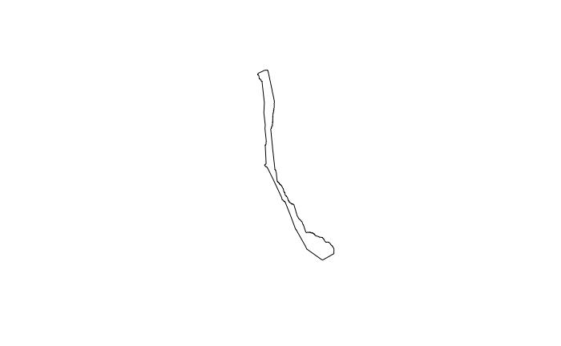

```r
#if any values are -Inf, change to NA
invisible(lapply(names(region_stats),function(.name) set(region_stats, which(is.infinite(region_stats[[.name]])), j = .name,value =NA)))


saveRDS(region_stats, here::here("output","region_stats","region_stats.rds"))

#or pull in
region_stats <- readRDS(here::here("output","region_stats","region_stats.rds"))


#test plot
plot(conc)
```

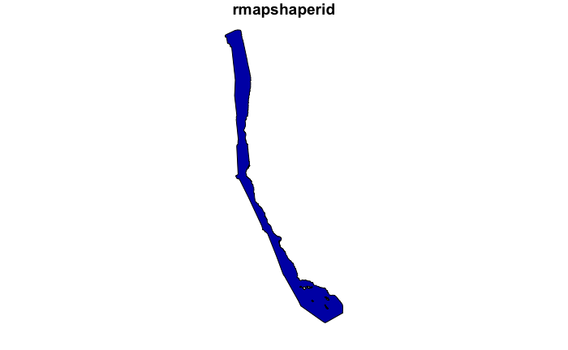

```r
plot(conc_nooverlap)
```

Calculate annual area of sampling (This takes a while which is why most is hashed out)

```r
##set up empty data table with year and region
# region_area_byyear <- data.table(survey_unit = as.character(),year = as.numeric(), area_km = as.numeric())
#
#
# for (i in 1:length(all_survey_units)) {
#   reduced_FishGlob_clean.singleseasoned.10year <- FishGlob_clean.singleseason[survey_unit == all_survey_units[i]]
#
#   #then, year
#   survey_years <- unique(reduced_FishGlob_clean.singleseasoned.10year$year)
#
#   #data table to fill
#
#       #single table
#     region_area_byyear_single <- as.data.table(matrix(nrow = length(survey_years)))
#     region_area_byyear_single[,survey_unit := all_survey_units[i]][,year := as.integer(V1)][,area_km := as.numeric(V1)][,V1 := NULL]
#
#
#   for (j in 1:length(survey_years)) {
#     #single year
#     FishGlob_1year <- reduced_FishGlob_clean.singleseasoned.10year[year == survey_years[j],]
#
#         #fix those that cross dateline
#     FishGlob_1year[,long_range := max(longitude)-min(longitude)]
#     FishGlob_1year[,long_shift := ifelse(long_range >300 & longitude > 0, longitude - 360, longitude)]
#
#         ####unique lat lon
#     lat_lon <- unique(FishGlob_1year[,.(latitude, long_shift)])
#
#     pts <- st_as_sf(lat_lon, coords=c('long_shift','latitude'), crs=4326 )
#
#     conc <- concaveman(pts, 1,2)
#
#     #delete areas that overlap with land
#     conc_nooverlap <- ms_erase(conc,world[1])
#
#     sf_use_s2(FALSE) #helps with spherical geometry
#     area <- st_area(conc_nooverlap) #m2
#
#     #compile into region_Stats table
#                   region_area_byyear_single[j,"year"] <- as.numeric(survey_years[j])
#                   region_area_byyear_single[j,"area_km"] <- as.numeric(area/(1000^2))
#
#                   paste0(all_survey_units[i],", ", "year ", j, " out of ",length(survey_years))
#   }
#   #merge across surveys
#   region_area_byyear <- rbind(region_area_byyear, region_area_byyear_single)
#                   }
#
#
# fwrite(region_area_byyear, file = here::here("output","region_area_byyear.csv"))

#or, read in
region_area_byyear <- fread(file = here::here("output","region_area_byyear.csv"))
```

Merge region stats with dissimilarities

```r
#region_statistics
dissimilarities_temp_fishing_regstats <- dissimilarities_temp_fishing[region_stats, on = "survey_unit"]
dissimilarities_temp_fishing_regstats[,spp_num.s := scale(spp_num)]

dissimilarities_temp_fishing_regstats[,annual_dissimilarity_value.s := scale(annual_dissimilarity_value, center = F),.(survey_unit,dissimilarity_metric)]

dissimilarities_temp_fishing_regstats <- dissimilarities_temp_fishing_regstats[FishGlob_richness_year_survey, on = c("year","survey_unit")]

dissimilarities_temp_fishing_regstats[,spp_count_annual.s := scale(spp_count_annual)]

#save avg values
saveRDS(dissimilarities_temp_fishing_regstats, here::here("output","dissimilarities","dissimilarities_temp_fishing_regstats.rds"))
```

Add median Julian day and season

```r
FishGlob_clean.singleseason <- readRDS(here::here("data","cleaned","FishGlob_clean.singleseason.rds"))

dates_regions <- unique(FishGlob_clean.singleseason[,.(survey_unit, year, month, day, quarter, season)])
dates_regions[,day := ifelse(is.na(day),1,day)][survey_unit == "MEDITS",day := 15][survey_unit == "MEDITS",month := 5]

#calculate date, julian date, and avg julian date for survey
dates_regions[,date := ymd(paste(year,month,day,sep = "/"))][,julian := yday(date)][,avg_julian := mean(julian),.(survey_unit)][,avg_julian_annual := mean(julian),.(survey_unit, year)]

#calculate season
so_hemis <- c("CHL","NAM","NZ-CHAT","NZ-ECSI","NZ-SUBA","NZ-WCSI","S-GEORG","ZAF-ATL","ZAF-IND")

#function for season
# Function to classify dates into seasons for Northern Hemisphere
get_season_northern <- function(date) {
  y <- year(date)
  winter_start <- as.Date(paste0(y-1, "-12-21"))
  spring_start <- as.Date(paste0(y, "-03-21"))
  summer_start <- as.Date(paste0(y, "-06-21"))
  autumn_start <- as.Date(paste0(y, "-09-21"))
  autumn_end <- as.Date(paste0(y, "-12-20"))

  if (date >= winter_start & date < spring_start) {
    return("Winter")
  } else if (date >= spring_start & date < summer_start) {
    return("Spring")
  } else if (date >= summer_start & date < autumn_start) {
    return("Summer")
  } else if (date >= autumn_start & date < autumn_end) {
    return("Fall")
  } else {
    return("Winter")
  }
}

# Function to classify dates into seasons for southern Hemisphere
get_season_southern <- function(date) {
  y <- year(date)
  winter_start <- as.Date(paste0(y-1, "-12-21"))
  spring_start <- as.Date(paste0(y, "-03-21"))
  summer_start <- as.Date(paste0(y, "-06-21"))
  autumn_start <- as.Date(paste0(y, "-09-21"))
  autumn_end <- as.Date(paste0(y, "-12-20"))

  if (date >= winter_start & date < spring_start) {
    return("Summer")
  } else if (date >= spring_start & date < summer_start) {
    return("Fall")
  } else if (date >= summer_start & date < autumn_start) {
    return("Winter")
  } else if (date >= autumn_start & date < autumn_end) {
    return("Spring")
  } else {
    return("Summer")
  }
}


#get season
dates_regions[, season := mapply(function(date, survey_unit) {
  if (survey_unit %in% so_hemis) {
    get_season_southern(date)
  } else {
    get_season_northern(date)
  }
}, date, survey_unit)]


#save
saveRDS(dates_regions, here::here("output","dates_regions.rds"))

#Identify primary season per survey
seasons_regions <- dates_regions[ , .(season_freq = .N),
  by = .(survey_unit, season, avg_julian)
  ][, season_rank := frank(-season_freq, ties.method = 'min'),
    keyby = survey_unit
    ][season_rank ==1,][,.(survey_unit,season, avg_julian)]

#merge with region stats and coefficients in that data table
region_stats <- seasons_regions[region_stats, on = "survey_unit"]
```

Format region_stats for paper supplement

```r
region_stats.format <- copy(region_stats)

region_stats.format <- region_stats[color_link, on = "survey_unit", nomatch = F]

region_stats.format[,`Mean annual CPUE (num in 1000s/km^2)`:=round(mean_annual_cpue/1000,0)][,`Mean annual tow count` := round(mean_haul_id_count_annual)][,`Mean annual tow density (tows/km^2)` := signif(mean_haul_density,2)][,`SD annual tow density (tows/km^2)` := signif(SD_haul_density,2)][,`Latitude range (˚)`:= round(lat_range,0)][,`Longitude range (˚)`:=round(lon_range,0)][,`Area (1000s of kms)`:=round(area_km/1000,0)][,`Mid-depth (m)`:= round(mid_depth,0)][,`Depth range (m)`:= round(depth_range,0)][,`Mid-latitude (˚N)`:= round(mid_lat,0)][,`Mean bottom temperature (˚C)`:= round(mean_temp,1)][,`Mean annual fisheries catch (1000s of tonnes)`:= round(mean_catch/1000,0)][,`Number of species across all years`:= spp_num][,`Survey length (years)`:=study_period][,`Total years sampled`:=years_sampled][,`First year`:=first_year][,`Last year`:=last_year][,`Mean Julian day`:= round(avg_julian,0)][,`Primary season`:= season]

setorder(region_stats.format, survey_unit)

region_stats.format <- region_stats.format[,.(Survey_Name_Season, `First year`,`Last year`,`Mean Julian day`,`Primary season`, `Survey length (years)`, `Total years sampled`, `Latitude range (˚)`, `Longitude range (˚)`, `Mid-latitude (˚N)`,`Depth range (m)`, `Mid-depth (m)`, `Area (1000s of kms)`, `Mean bottom temperature (˚C)`,`Number of species across all years`,`Mean annual CPUE (num in 1000s/km^2)`,`Mean annual tow count`,`Mean annual tow density (tows/km^2)`,`SD annual tow density (tows/km^2)`, `Mean annual fisheries catch (1000s of tonnes)`)]


View(region_stats.format)

colnames(region_stats.format)
```

```
 [1] "Survey_Name_Season"                            "First year"                                    "Last year"
 [4] "Mean Julian day"                               "Primary season"                                "Survey length (years)"
 [7] "Total years sampled"                           "Latitude range (˚)"                            "Longitude range (˚)"
[10] "Mid-latitude (˚N)"                             "Depth range (m)"                               "Mid-depth (m)"
[13] "Area (1000s of kms)"                           "Mean bottom temperature (˚C)"                  "Number of species across all years"
[16] "Mean annual CPUE (num in 1000s/km^2)"          "Mean annual tow count"                         "Mean annual tow density (tows/km^2)"
[19] "SD annual tow density (tows/km^2)"             "Mean annual fisheries catch (1000s of tonnes)"
```

```r
#export to csv
fwrite(region_stats.format, here::here("output","region_stats","region_stats.format.csv"))
```

Proportion test (prop homogenizing/differentiating vs. prop not)

H0: The null hypothesis is that the two hemispheres from which the regions were drawn have the same true proportion of homogenizers. A: The alternative is that this proportion is different in at least one of the hemispheres.

H0: The null hypothesis is that the two hemispheres from which the regions were drawn have the same true proportion of differentiators. A: The alternative is that this proportion is different in at least one of the hemispheres.